# Untitled

kk

6/3/2020

Student ID = 29949637 Title = ETC 3550 retail forecasting project

```r
library(dplyr)
library(fpp3)
```

```r
library(ggplot2)
```

```r
set.seed(29949637)
myseries <- aus_retail %>%
  filter(
    `Series ID` == sample(aus_retail$`Series ID`,1),
    Month < yearmonth("2018 Jan")
  )
my_series <- myseries %>%
summarise(Turnover = sum(Turnover))
```

1. statistical features of the data

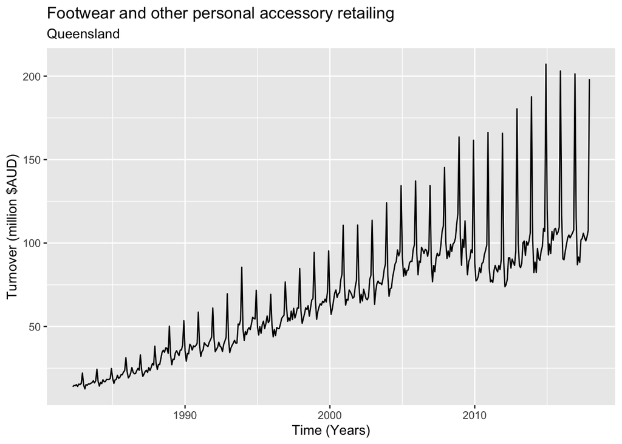

```r
myseries %>%
  autoplot(Turnover) +
  labs(y = "Turnover (million $AUD)", x = "Time (Years)",
       title = myseries$Industry[1],
       subtitle = myseries$State[1])
```

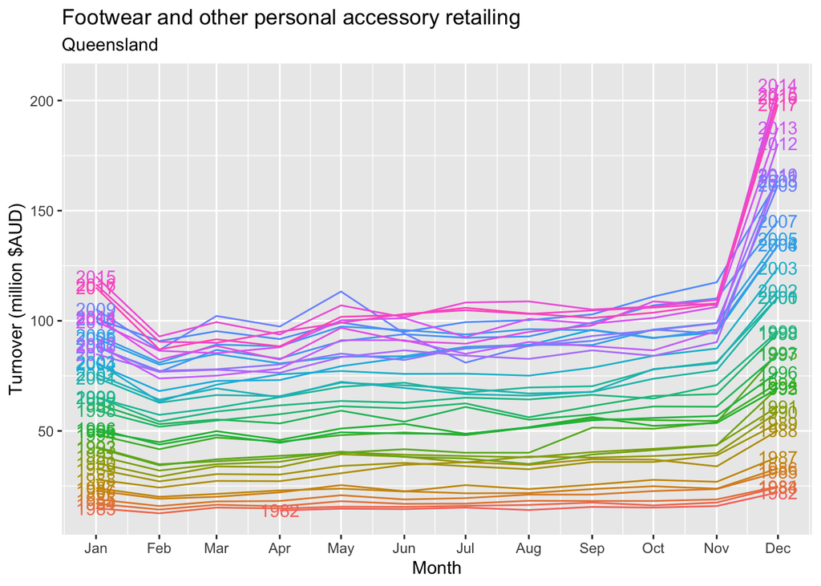

```r
myseries %>%
  gg_season(Turnover, labels = "both") +
  labs(y = "Turnover (million $AUD)",
       title = myseries$Industry[1],
       subtitle = myseries$State[1])
```

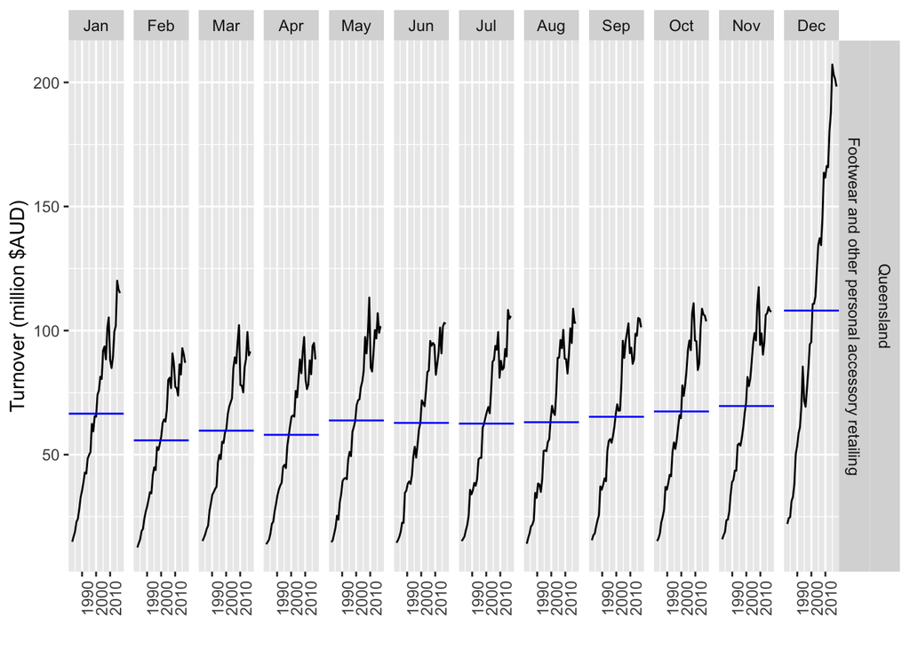

```r
myseries %>%
  gg_subseries(Turnover) +
  labs(y = "Turnover (million $AUD)", x="")
```

```
## Plot variable not specified, automatically selected `y = Turnover`
```

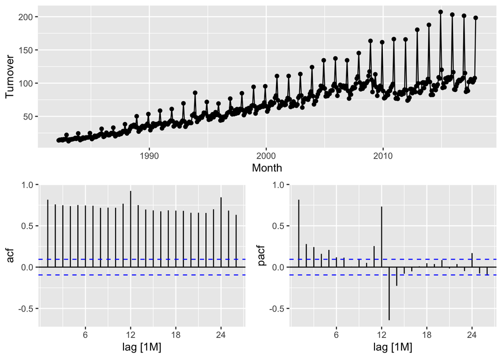

```r
my_series %>% gg_tsdisplay(plot_type = 'partial')
```

2. transformation and differencing

```r
myseries %>%
  features(Turnover, features = guerrero)
```

```
## # A tibble: 1 x 3
##   State      Industry                                       lambda_guerrero
##   <chr>      <chr>                                                    <dbl>
## 1 Queensland Footwear and other personal accessory retaili…          -0.282
```

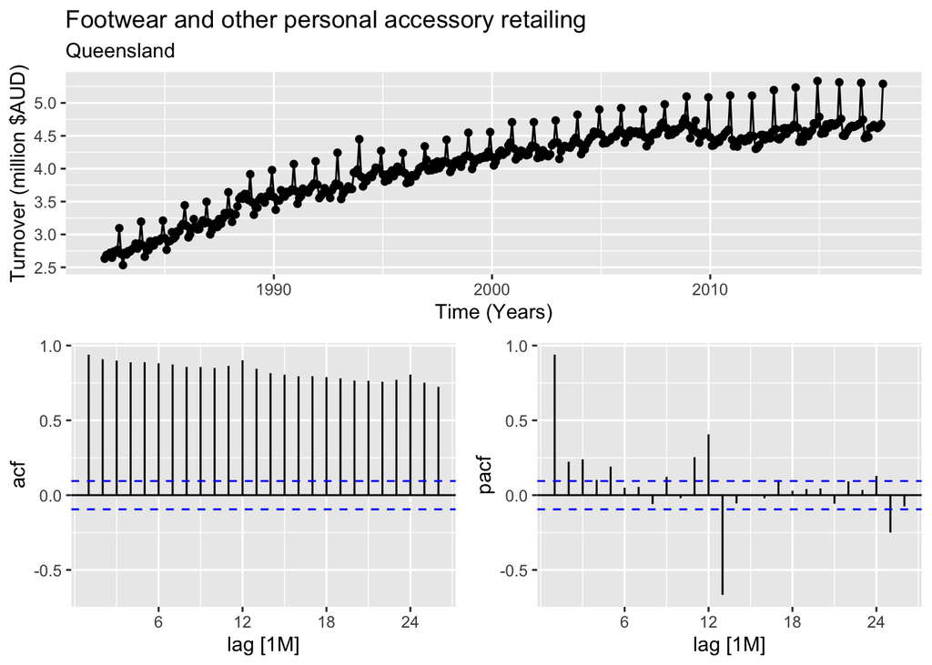

```r
my_series %>% gg_tsdisplay(log(Turnover),plot_type = 'partial')+
  labs(y = "Turnover (million $AUD)", x = "Time (Years)",
       title = myseries$Industry[1],
       subtitle = myseries$State[1])
```

```r
myseries %>% features(log(Turnover), list(unitroot_ndiffs, unitroot_nsdiffs))
```

```
## # A tibble: 1 x 4
##   State      Industry                                        ndiffs nsdiffs
##   <chr>      <chr>                                            <int>   <int>
## 1 Queensland Footwear and other personal accessory retailing      1       1
```

The data has increasing variability over time , which means it need at transformation , and it has a seasonal pattern with 12 lags , therefore seasonal differencing is needed , we also test for normal differencing with unitroot test

after differencing & transformation

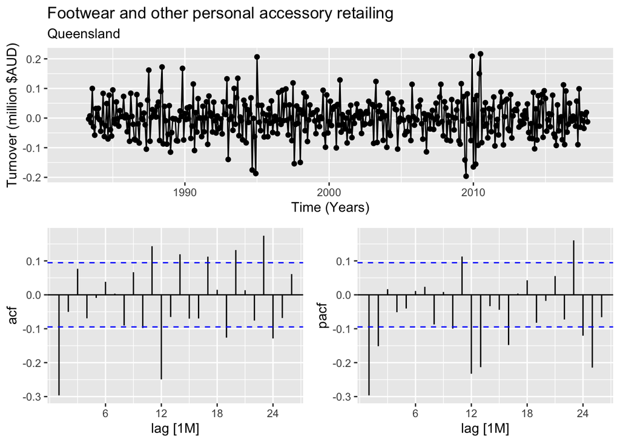

```r
myseries %>% gg_tsdisplay(log(Turnover) %>% difference(12) %>% difference(),
  plot_type='partial')+
  labs(y = "Turnover (million $AUD)", x = "Time (Years)",
       title = myseries$Industry[1],
       subtitle = myseries$State[1])
```

we are using log transformation , because after using guerero function we found iut that the lambda is close to 0 , therefore log transformation is still appropritate , after the log and differencing , the data looks more stationary

creating test set

```r
myseries_train <- my_series %>%
  filter(Month <= max(Month)-24)
```

3 .Creating model for forecast autochoosing best model , based on AIC

```r
myseries_train %>%
  model(ETS(Turnover)) %>%
report()
```

```
## Series: Turnover
## Model: ETS(M,A,M)
##   Smoothing parameters:
##     alpha = 0.4255201
##     beta  = 0.0001000497
##     gamma = 0.4662814
##
##   Initial states:
##         l         b        s1        s2        s3       s4       s5
##  15.03817 0.1911032 0.9401898 0.7863468 0.9351491 1.404214 1.058087
##        s6       s7        s8        s9       s10       s11       s12
##  1.015371 1.028047 0.9691469 0.9796729 0.9375557 0.9784476 0.9677713
##
##   sigma^2:  0.0031
##
##      AIC     AICc      BIC
## 3353.512 3355.093 3421.578
```

```r
myseries_train %>%
  model(
    arima_auto = ARIMA(log(Turnover) ~ pdq(0:5,0:2,0:5) + PDQ(P = 0:5, 0:2, Q = 0:5, period = NULL))) %>%
  report()
```

```
## Series: Turnover
## Model: ARIMA(0,1,2)(0,1,2)[12]
## Transformation: log(.x)
##
## Coefficients:
##           ma1      ma2     sma1     sma2
##       -0.3655  -0.0886  -0.4846  -0.2249
## s.e.   0.0515   0.0555   0.0506   0.0504
##
## sigma^2 estimated as 0.002785:  log likelihood=595.3
## AIC=-1180.61   AICc=-1180.45   BIC=-1160.75
```

creating other model for forecast

creating ets model ( MAM , MAdM , MNM , auto ) & ARIMA model

```r
fit <- myseries_train %>%
  model(
    MAM = ETS(Turnover ~ error("M") + trend("A") + season("M")),
    MAdM = ETS(Turnover ~ error("M") + trend("Ad") + season("M")),
    MNM = ETS(Turnover ~ error("M") + trend("N") + season("M")),
    auto = ETS(Turnover))
glance(fit)
```

```
## # A tibble: 4 x 9
##   .model  sigma2 log_ik   AIC  AICc   BIC   MSE  AMSE    MAE
##   <chr>    <dbl>  <dbl> <dbl> <dbl> <dbl> <dbl> <dbl>  <dbl>
## 1 MAM    0.00310 -1660. 3354. 3355. 3422.  18.5  23.5 0.0411
## 2 MAdM   0.00319 -1663. 3362. 3364. 3434.  18.8  24.1 0.0416
## 3 MNM    0.00364 -1689. 3408. 3410. 3468.  19.4  24.2 0.0448
## 4 auto   0.00310 -1660. 3354. 3355. 3422.  18.5  23.5 0.0411
```

```r
fit %>%
  forecast(h = 24) %>%
  accuracy(my_series)
```

```
## # A tibble: 4 x 9
##   .model .type      ME  RMSE   MAE     MPE  MAPE  MASE    ACF1
##   <chr>  <chr>   <dbl> <dbl> <dbl>   <dbl> <dbl> <dbl>   <dbl>
## 1 auto   Test  -2.13    4.70  3.73 -1.72    3.30 0.735  0.220
## 2 MAdM   Test   0.134   3.07  2.50  0.298   2.27 0.492 -0.0190
## 3 MAM    Test  -2.13    4.70  3.73 -1.72    3.30 0.735  0.220
## 4 MNM    Test  -0.0752  2.93  2.55  0.0267  2.36 0.502 -0.0778
```

```r
fit2 <- myseries_train %>%
  model(
    arima_auto = ARIMA(log(Turnover) ~ pdq(0:5,0:2,0:5) + PDQ(P = 0:2, 0:2, Q = 0:2, period = NULL)),
   arima_012_012 = ARIMA(log(Turnover) ~ pdq(0,1,2) + PDQ(P = 0, 1, Q = 2, period = 12))     ,
   arima_012_111 = ARIMA(log(Turnover) ~ pdq(0,1,2) + PDQ(P = 1, 1, Q = 1, period = 12)),
   arima_111_012 = ARIMA(log(Turnover) ~ pdq(1,1,1) + PDQ(P = 1, 1, Q = 1, period = 12)))
fit7 <-fit2%>% forecast(h=24)
fit2 %>%glance()
```

```
## # A tibble: 4 x 8
##   .model         sigma2 log_lik    AIC   AICc    BIC ar_roots   ma_roots
##   <chr>           <dbl>   <dbl>  <dbl>  <dbl>  <dbl> <list>     <list>
## 1 arima_auto    0.00278    595. -1181. -1180. -1161. <cpl [0]>  <cpl [26]>
## 2 arima_012_012 0.00278    595. -1181. -1180. -1161. <cpl [0]>  <cpl [26]>
## 3 arima_012_111 0.00278    596. -1181. -1181. -1161. <cpl [12]> <cpl [14]>
## 4 arima_111_012 0.00278    596. -1181. -1181. -1161. <cpl [13]> <cpl [13]>
```

```r
fit7 %>%accuracy(my_series)
```

```
## # A tibble: 4 x 9
##   .model        .type    ME  RMSE   MAE   MPE  MAPE  MASE  ACF1
##   <chr>         <chr> <dbl> <dbl> <dbl> <dbl> <dbl> <dbl> <dbl>
## 1 arima_012_012 Test  -8.17  9.18  8.17 -7.83  7.83  1.61 0.360
## 2 arima_012_111 Test  -8.62  9.63  8.62 -8.31  8.31  1.70 0.421
## 3 arima_111_012 Test  -8.85  9.85  8.85 -8.53  8.53  1.74 0.425
## 4 arima_auto    Test  -8.17  9.18  8.17 -7.83  7.83  1.61 0.360
```

For the choosing of appropriate ARIMA & ETS model , first we create the auto method which r comput by optimizing the lowest aic value, Then we create a shortlist of ARIMA & ETS model to check for their AIC , RMSE

for ARIMA , from the myseries plot we know that there is a need of log transformation and to 1 time seasonal differencing & 1 time differencing , from the ACf & PACF plot , we could see there are some significant lag with seasonallity of 12 months , so we use ARIMA(0,1,2)(0,1,2)[12] , ARIMA(0,1,2)(1,1,1)[12] , ARIMA(1,1,1)(1,1,1)[12]

for ets , looking at the myseries plot , we could conclude that there is a multiplicative error & seasonality , so we use ETS(MAM), ETS(MAdM), ETS(MNM)

After applying the model to the test set , for the ARIMA(0,1,2)(0,1,2)[12] has the lowest RMSE in the ARIMA method , so we conclude that this is indeed the best ARIMA method for the data , while for the ETS method MAdM has lower RMSE but higher AIC , using this as a consideration , we still choose the ETS(MAM) as the better method as we’d probably go with the ETS(M,A,M) model, simply because we expected think turnover will continue to increase due to population increases.

4. choose one model & show we choose MAM & ARIMA (0,1,2)(0,1,2) with 12 lags

```r
fit_ets <- myseries_train %>%
  model(ETS(Turnover ~ error("M") + trend("A") + season("M")))
report(fit_ets)
```

```
## Series: Turnover
## Model: ETS(M,A,M)
##   Smoothing parameters:
##     alpha = 0.4255201
##     beta  = 0.0001000497
##     gamma = 0.4662814
##
##   Initial states:
##         l         b        s1        s2        s3       s4       s5
##  15.03817 0.1911032 0.9401898 0.7863468 0.9351491 1.404214 1.058087
##        s6       s7        s8        s9       s10       s11       s12
##  1.015371 1.028047 0.9691469 0.9796729 0.9375557 0.9784476 0.9677713
##
##   sigma^2:  0.0031
##
##      AIC     AICc      BIC
## 3353.512 3355.093 3421.578
```

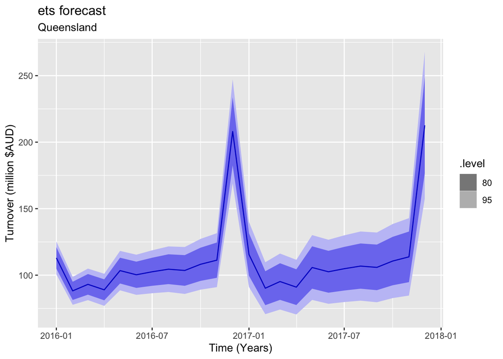

```r
fit_ets%>% forecast(h=24, level = 80)%>% autoplot()+labs(y = "Turnover (million $AUD)", x = "Time (Years)",
       title = "ets forecast",
       subtitle = myseries$State[1])
```

```r
fit_arima <- myseries_train %>%
  model(ARIMA(log(Turnover) ~ pdq(0,1,2) + PDQ(P = 0, 1, Q = 2, period = NULL))  )
fit_arima %>%report()
```

```
## Series: Turnover
## Model: ARIMA(0,1,2)(0,1,2)[12]
## Transformation: log(.x)
##
## Coefficients:
##           ma1      ma2     sma1     sma2
##       -0.3655  -0.0886  -0.4846  -0.2249
## s.e.   0.0515   0.0555   0.0506   0.0504
##
## sigma^2 estimated as 0.002785:  log likelihood=595.3
## AIC=-1180.61   AICc=-1180.45   BIC=-1160.75
```

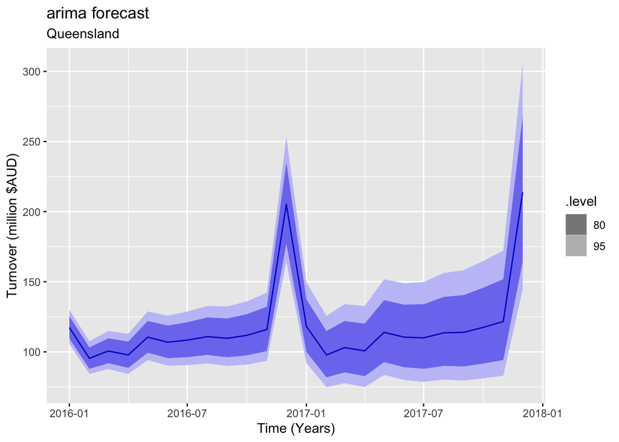

```r
fit_arima%>% forecast(h=24, level = 80)%>% autoplot()+
  labs(y = "Turnover (million $AUD)", x = "Time (Years)",
       title = "arima forecast",
       subtitle = myseries$State[1])
```

```r
tidy(fit_arima)
```

```
## # A tibble: 4 x 6
##   .model                        term  estimate std.error statistic  p.value
##   <chr>                         <chr>    <dbl>     <dbl>     <dbl>    <dbl>
## 1 ARIMA(log(Turnover) ~ pdq(0,… ma1    -0.365     0.0515     -7.10 6.12e-12
## 2 ARIMA(log(Turnover) ~ pdq(0,… ma2    -0.0886    0.0555     -1.60 1.11e- 1
## 3 ARIMA(log(Turnover) ~ pdq(0,… sma1   -0.485     0.0506     -9.58 1.23e-19
## 4 ARIMA(log(Turnover) ~ pdq(0,… sma2   -0.225     0.0504     -4.46 1.05e- 5
```

```r
tidy(fit_ets)
```

```
## # A tibble: 16 x 3
##    .model                                                    term  estimate
##    <chr>                                                     <chr>    <dbl>
##  1 "ETS(Turnover ~ error(\"M\") + trend(\"A\") + season(\"M… alpha  4.26e-1
##  2 "ETS(Turnover ~ error(\"M\") + trend(\"A\") + season(\"M… beta   1.00e-4
##  3 "ETS(Turnover ~ error(\"M\") + trend(\"A\") + season(\"M… gamma  4.66e-1
##  4 "ETS(Turnover ~ error(\"M\") + trend(\"A\") + season(\"M… l      1.50e+1
##  5 "ETS(Turnover ~ error(\"M\") + trend(\"A\") + season(\"M… b      1.91e-1
##  6 "ETS(Turnover ~ error(\"M\") + trend(\"A\") + season(\"M… s0     9.40e-1
##  7 "ETS(Turnover ~ error(\"M\") + trend(\"A\") + season(\"M… s1     7.86e-1
##  8 "ETS(Turnover ~ error(\"M\") + trend(\"A\") + season(\"M… s2     9.35e-1
##  9 "ETS(Turnover ~ error(\"M\") + trend(\"A\") + season(\"M… s3     1.40e+0
## 10 "ETS(Turnover ~ error(\"M\") + trend(\"A\") + season(\"M… s4     1.06e+0
## 11 "ETS(Turnover ~ error(\"M\") + trend(\"A\") + season(\"M… s5     1.02e+0
## 12 "ETS(Turnover ~ error(\"M\") + trend(\"A\") + season(\"M… s6     1.03e+0
## 13 "ETS(Turnover ~ error(\"M\") + trend(\"A\") + season(\"M… s7     9.69e-1
## 14 "ETS(Turnover ~ error(\"M\") + trend(\"A\") + season(\"M… s8     9.80e-1
## 15 "ETS(Turnover ~ error(\"M\") + trend(\"A\") + season(\"M… s9     9.38e-1
## 16 "ETS(Turnover ~ error(\"M\") + trend(\"A\") + season(\"M… s10    9.78e-1
```

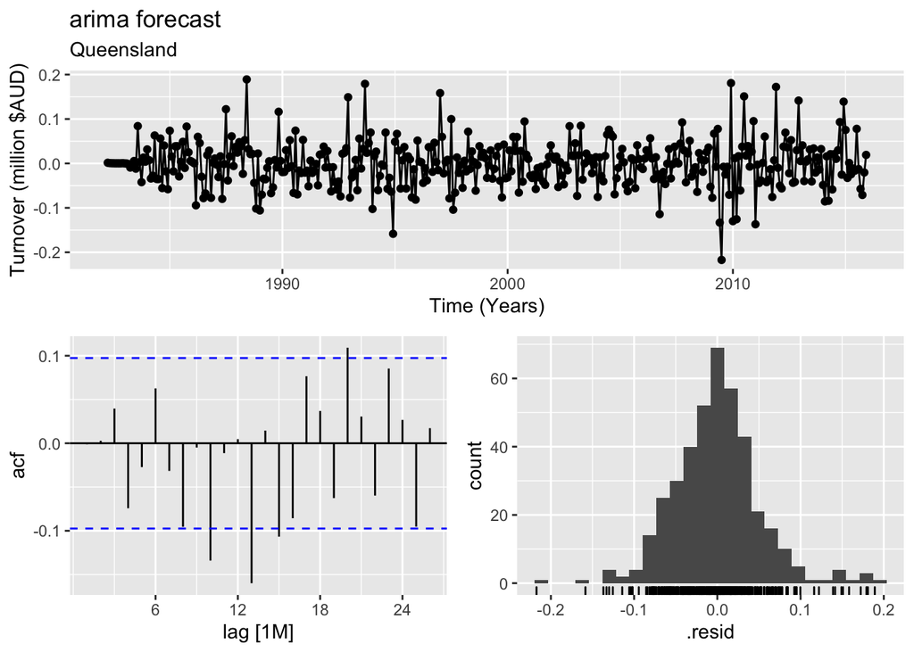

```r
fit_arima%>% gg_tsresiduals()+
  labs(y = "Turnover (million $AUD)", x = "Time (Years)",
       title = "arima forecast",
       subtitle = myseries$State[1])
```

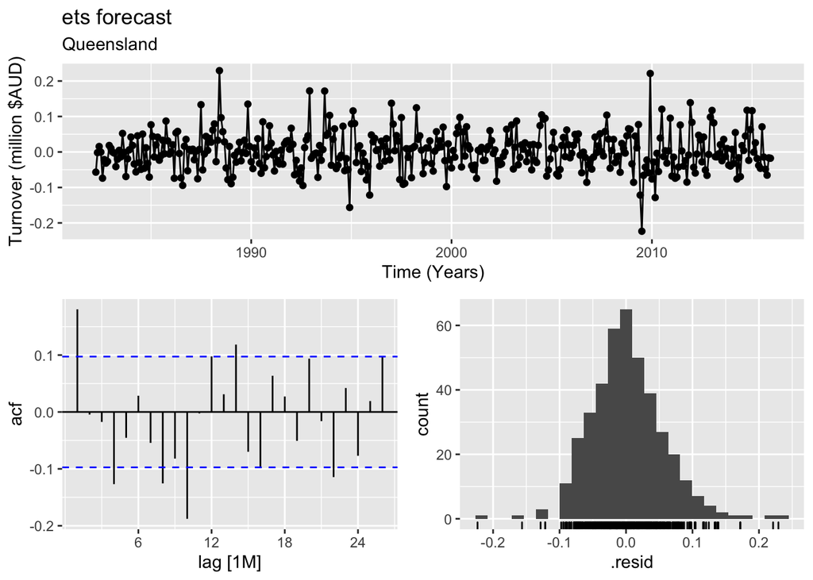

```r
fit_ets%>% gg_tsresiduals()+
  labs(y = "Turnover (million $AUD)", x = "Time (Years)",
       title = "ets forecast",
       subtitle = myseries$State[1])
```

```r
augment(fit_arima) %>%
  features(.resid, ljung_box, lag = 12, dof = 6)
```

```
## # A tibble: 1 x 3
##   .model                                                  lb_stat lb_pvalue
##   <chr>                                                     <dbl>     <dbl>
## 1 ARIMA(log(Turnover) ~ pdq(0, 1, 2) + PDQ(P = 0, 1, Q =…    16.6    0.0109
```

```r
augment(fit_ets) %>%
  features(.resid, ljung_box, lag = 12, dof = 16)
```

```
## # A tibble: 1 x 3
##   .model                                                  lb_stat lb_pvalue
##   <chr>                                                     <dbl>     <dbl>
## 1 "ETS(Turnover ~ error(\"M\") + trend(\"A\") + season(\…    50.5       NaN
```

5.comparing ARIMA & ETS

```r
fit_arima %>%forecast(h=24, level = 80) %>% accuracy(my_series)
```

```
## # A tibble: 1 x 9
##   .model                    .type    ME  RMSE   MAE   MPE  MAPE  MASE  ACF1
##   <chr>                     <chr> <dbl> <dbl> <dbl> <dbl> <dbl> <dbl> <dbl>
## 1 ARIMA(log(Turnover) ~ pd… Test  -8.17  9.18  8.17 -7.83  7.83  1.61 0.360
```

```r
fit_ets %>%forecast(h=24, level = 80) %>% accuracy(my_series)
```

```
## # A tibble: 1 x 9
##   .model                    .type    ME  RMSE   MAE   MPE  MAPE  MASE  ACF1
##   <chr>                     <chr> <dbl> <dbl> <dbl> <dbl> <dbl> <dbl> <dbl>
## 1 "ETS(Turnover ~ error(\"… Test  -2.13  4.70  3.73 -1.72  3.30 0.735 0.220
```

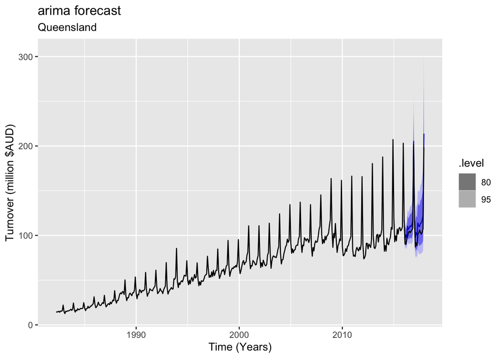

```r
fit_ARIMA <-fit_arima%>% forecast(h=24, level = 80)%>%
  autoplot(my_series)+
  labs(y = "Turnover (million $AUD)", x = "Time (Years)",
       title = "arima forecast",
       subtitle = myseries$State[1])

fit_ETS<-fit_ets%>% forecast(h=24, level = 80)%>%
  autoplot(my_series) +
  labs(y = "Turnover (million $AUD)", x = "Time (Years)",
       title = "ets forecast",
       subtitle = myseries$State[1])

fit_ARIMA
```

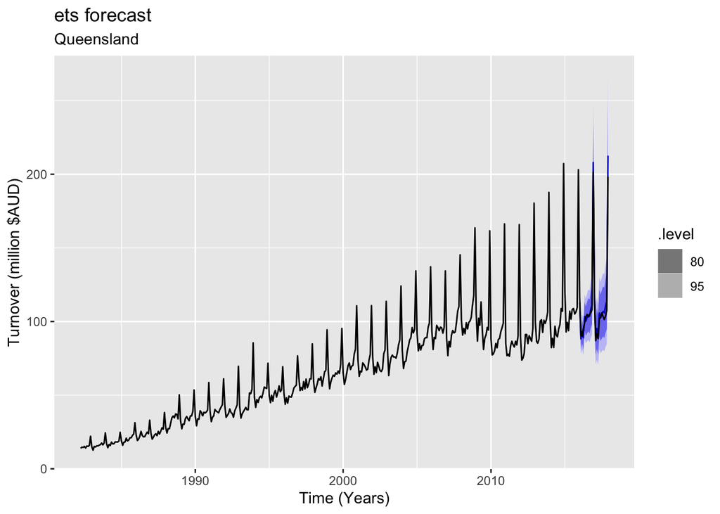

```r
fit_ETS
```

Looking at both of the model , the ETS model has bettes RMSE , MASE & MAPE value also looking at the plot after comparing them with the test set data , we could see that the ETS has been better in predicting the test set data , since they are relatively closer to the test set data than the arima model With this , we can conclude that ets has done a better job in predicting the test set data than arima

6.produce the forecast wuth full dataset

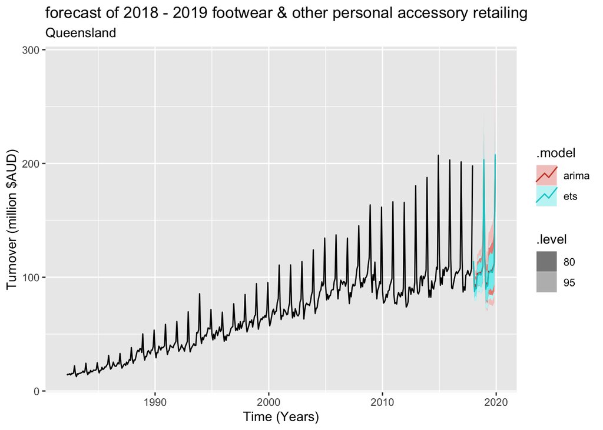

```r
fit_new <-my_series %>%
  model(
    arima= ARIMA(log(Turnover) ~ pdq(0,1,2) + PDQ(P = 0, 1, Q = 2, period = NULL)),

    ets= ETS(Turnover ~ error("M") + trend("A") + season("M"))                                               )
fit_fc <-fit_new %>% forecast(h=24 ,level = 80) %>% autoplot(tail(my_series,429))+ labs(y = "Turnover (million $AUD)", x = "Time (Years)",
       title = "forecast of 2018 - 2019 footwear & other personal accessory retailing",
       subtitle = myseries$State[1])


fit_fc
```

```r
fit_new %>% forecast(h=24 ,level = 80)
```

```
## # A fable: 48 x 4 [1M]
## # Key:     .model [2]
##    .model    Month Turnover .distribution
##    <chr>     <mth>    <dbl> <dist>
##  1 arima  2018 Jan    113.  t(N(4.7, 0.0027))
##  2 arima  2018 Feb     88.8 t(N(4.5, 0.0038))
##  3 arima  2018 Mar     93.3 t(N(4.5, 0.0046))
##  4 arima  2018 Apr     90.9 t(N(4.5, 0.0054))
##  5 arima  2018 May    103.  t(N(4.6, 0.0062))
##  6 arima  2018 Jun    103.  t(N(4.6, 0.0070))
##  7 arima  2018 Jul    104.  t(N(4.6, 0.0078))
##  8 arima  2018 Aug    104.  t(N(4.6, 0.0086))
##  9 arima  2018 Sep    103.  t(N(4.6, 0.0094))
## 10 arima  2018 Oct    106.  t(N(4.7, 0.0101))
## # … with 38 more rows
```

the data aboce is forecast of 2 years from 2018 to 2019 of footwear & other personal accessory retailing in queensland with ETS(MAM) model & ARIMA(0,1,2)(0,1,2)[12] model under 80% confidence interval the data shows both the forecast and the plot

7.integrate the read_abs data

```r
Abs <- readabs::read_abs(series_id = "A3349719C")
```

```
## Finding filenames for tables corresponding to ABS series ID
```

```
## Attempting to download files from series ID , Retail Trade, Australia
```

```
## Extracting data from downloaded spreadsheets
```

```
## Tidying data from imported ABS spreadsheets
```

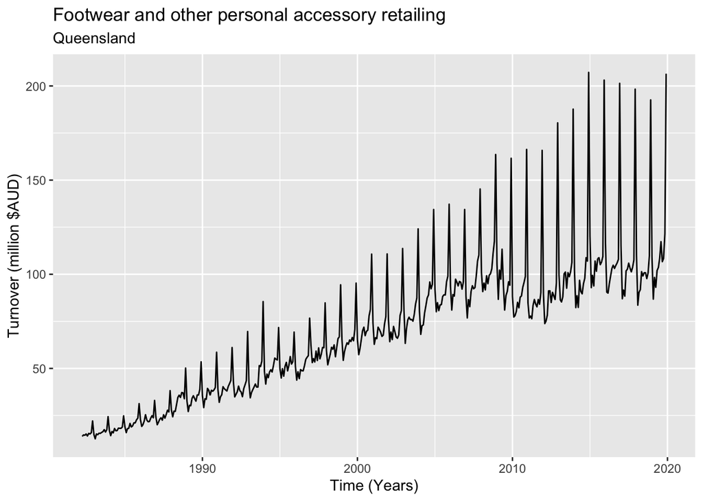

```r
set.seed(29949637)
test_abs <- Abs %>%
  select(date, value, series_id) %>%
  mutate(State = "Western Australia", Industry = "Footwear and other personal accessory retailing") %>%
  rename(
    Month = date,
    SeriesID = series_id,
    Turnover = value
  ) %>%
  mutate(Month = yearmonth(Month)) %>%
  as_tsibble(index=Month)

abs_data <- test_abs %>% filter(
    Month < yearmonth("2020 Jan"))


abs_data %>% autoplot(Turnover)+
  labs(y = "Turnover (million $AUD)", x = "Time (Years)",
       title = myseries$Industry[1],
       subtitle = myseries$State[1])
```

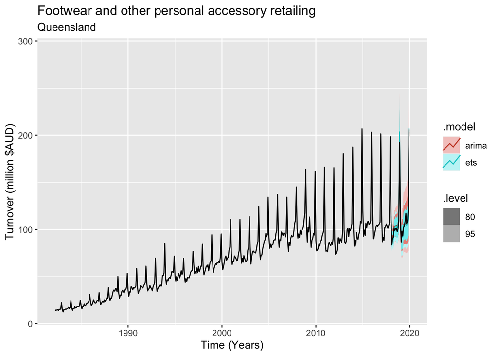

```r
#fit_fc %>% autoplot()
fit_new %>% forecast(h=24 ,level = 80) %>% autoplot(abs_data )+
  labs(y = "Turnover (million $AUD)", x = "Time (Years)",
       title = myseries$Industry[1],
       subtitle = myseries$State[1])
```

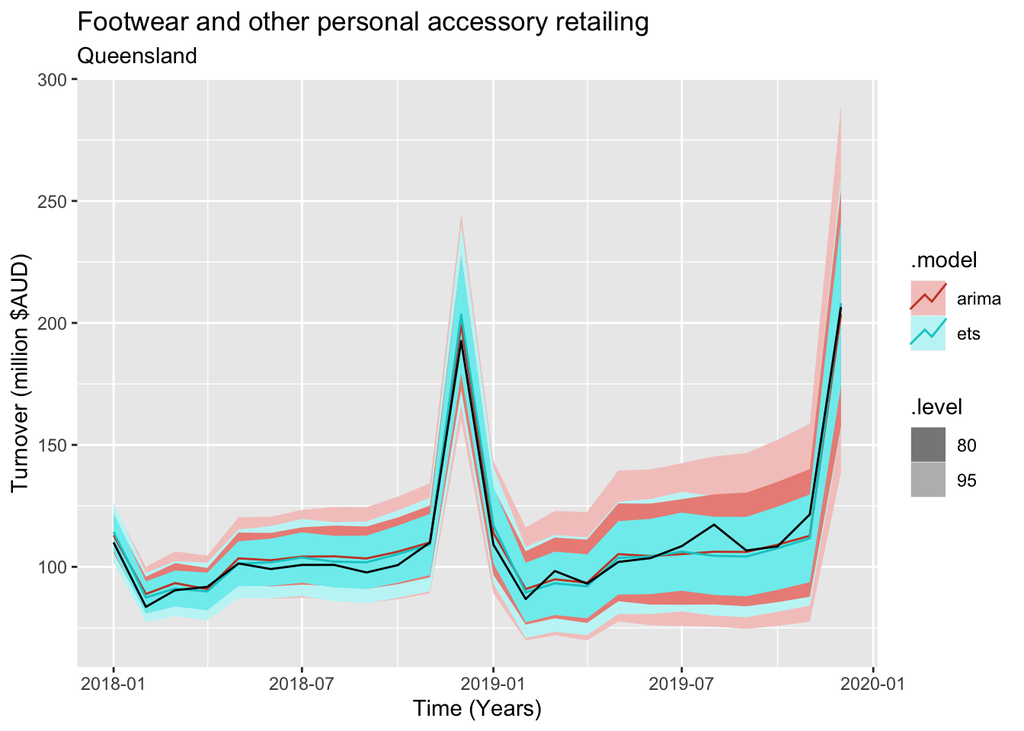

```r
abs_new <- test_abs %>% filter(
    Month < yearmonth("2020 Jan"),
     Month > yearmonth("2017 Dec"))
fit_new %>% forecast(h=24 ,level = 80) %>% autoplot(abs_new)+
  labs(y = "Turnover (million $AUD)", x = "Time (Years)",
       title = myseries$Industry[1],
       subtitle = myseries$State[1])
```

```r
fit_new %>% forecast(h=24 ,level = 80)%>% accuracy(abs_data)
```

```
## # A tibble: 2 x 9
##   .model .type     ME  RMSE   MAE    MPE  MAPE  MASE  ACF1
##   <chr>  <chr>  <dbl> <dbl> <dbl>  <dbl> <dbl> <dbl> <dbl>
## 1 arima  Test  -1.03   4.46  3.60 -1.15   3.32 0.728 0.404
## 2 ets    Test  -0.529  4.93  3.62 -0.443  3.22 0.731 0.325
```

Looking at the forecast above , we could say that both of the model did a pretty good job in forecasting the 2018 - 2019 data , they both capture the seasonal pattern which it goes up at the end of the year , & start declining while reaching a new year. The also somewhat capture the movement of the data in the early month of the year. Looking at the RMSE , ARIMA this time did a slightly better job than ETS , but both of them still has lower RMSE , which means thet did capture a lot of the data for the forecast.